# Milestone Report

Heidi Peterson

4/29/2020

Task 1: Getting and Cleaning the data

## basic summaries of the three files? Word counts, line counts and basic data tables

word count

line counts

Basic data Tables

```
##   File.Name     size num.lines num.words
## 1     blogs 200.4242    899288  37334131
## 2      news 196.2775   1010242  34372530
## 3   twitter 159.3641   2360148  30373583
```

## basic plots, such as histograms to illustrate features of the data

The sample size is going to be .1% of the total size. To save time. And because my Ram cannot handle the file #data sample

```
##           used (Mb) gc trigger  (Mb)  max used  (Mb)
## Ncells  593659 31.8    9569970 511.1  11962462 638.9
## Vcells 5296119 40.5  129315926 986.7 105362595 803.9
```

##Clean Sample

Save sample file

##Make Corpus

```
##           used (Mb) gc trigger  (Mb)  max used  (Mb)
## Ncells 1335840 71.4    7655976 408.9  11962462 638.9
## Vcells 6469240 49.4  103452741 789.3 105362595 803.9
```

#Task 2: Exploratory Data Analysis

Exploratory analysis - perform a thorough exploratory analysis of the data, understanding the distribution of words and relationship between the words in the corpora. ##Tokenization Build basic n-gram model - using the exploratory analysis you performed, build a basic n-gram model for predicting the next word based on the previous 1, 2, or 3 words. NGram Tokenizers - break the corpus into either a unigram, bigram, or trigram Term Document Matrix

Now we create the document-term matrix.

Understand frequencies of words and word pairs - build figures and tables to understand variation in the frequencies of words and word pairs in the data.

```
##           used (Mb) gc trigger  (Mb)  max used  (Mb)
## Ncells 1339519 71.6    6124781 327.1  11962462 638.9
## Vcells 6464462 49.4   82762193 631.5 105362595 803.9
```

Some words are more frequent than others - what are the distributions of word frequencies? What are the frequencies of 2-grams and 3-grams in the dataset?

```
##            used  (Mb) gc trigger   (Mb)  max used   (Mb)
## Ncells  1358111  72.6    3919860  209.4  11962462  638.9
## Vcells 68953368 526.1  159890687 1219.9 131595093 1004.0
```

```
##           used (Mb) gc trigger  (Mb)  max used   (Mb)
## Ncells 1358351 72.6    3919860 209.4  11962462  638.9
## Vcells 6525961 49.8  127912550 975.9 131595093 1004.0
```

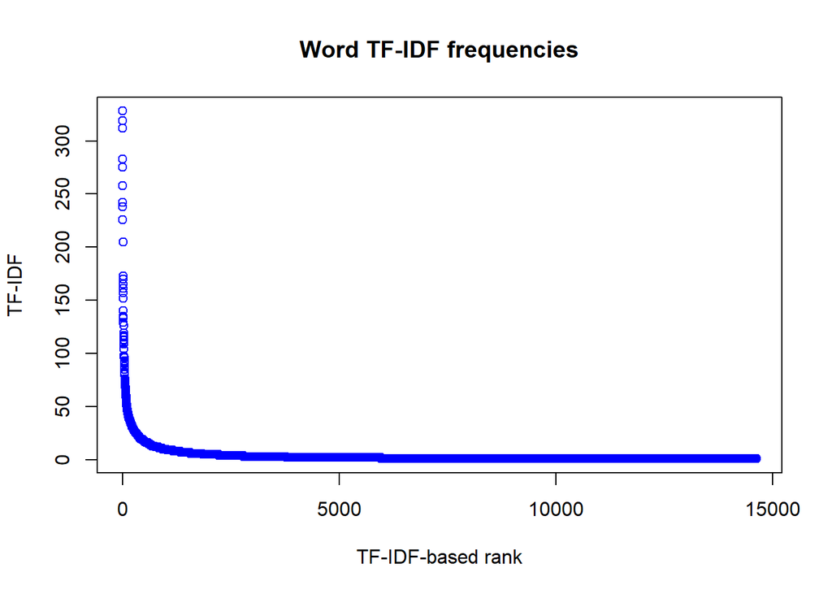

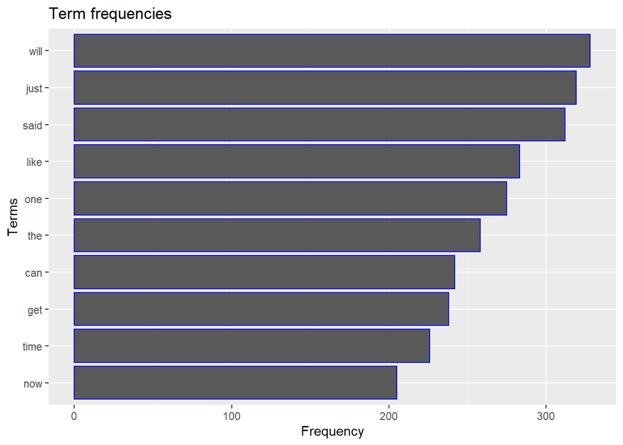

2-grams

```
##           used (Mb) gc trigger   (Mb)  max used   (Mb)
## Ncells 1511720 80.8    3919860  209.4  11962462  638.9
## Vcells 6940657 53.0  416767536 3179.7 432692960 3301.2
```

```
##  right now  last year  cant wait     i love  dont want first time
##         35         22         21         19         18         17
```

3-grams

```
##           used (Mb) gc trigger   (Mb)  max used   (Mb)
## Ncells 1560438 83.4    3919860  209.4  11962462  638.9
## Vcells 7216616 55.1  407498801 3109.0 432692960 3301.2
```

```
##         happy mothers day               i dont want            cant wait hear
##                         7                         6                         4
##               let us know        raw wednesdays raw wednesdays raw wednesdays
##                         4                         4                         4
```

How many unique words do you need in a frequency sorted dictionary to cover 50% of all word instances in the language? 90%?

```
## usually
##     909
```

```
## girded
##   9188
```

How do you evaluate how many of the words come from foreign languages? use tm to remove words as part of the english dictionary and subtract the difference.

Can you think of a way to increase the coverage – identifying words that may not be in the corpora or using a smaller number of words in the dictionary to cover the same number of phrases?

use a synonym dictionary and replace the synonyms with the most frequently used one.

Plot: Word Cloud 1-gram

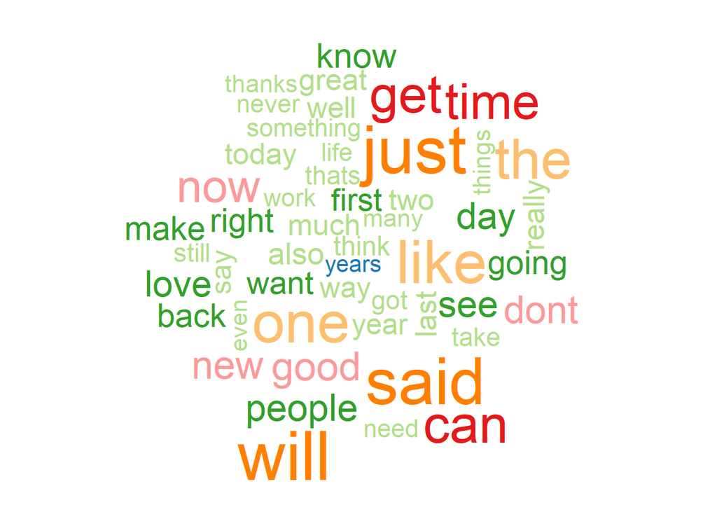

Plot: Word Cloud 2-gram

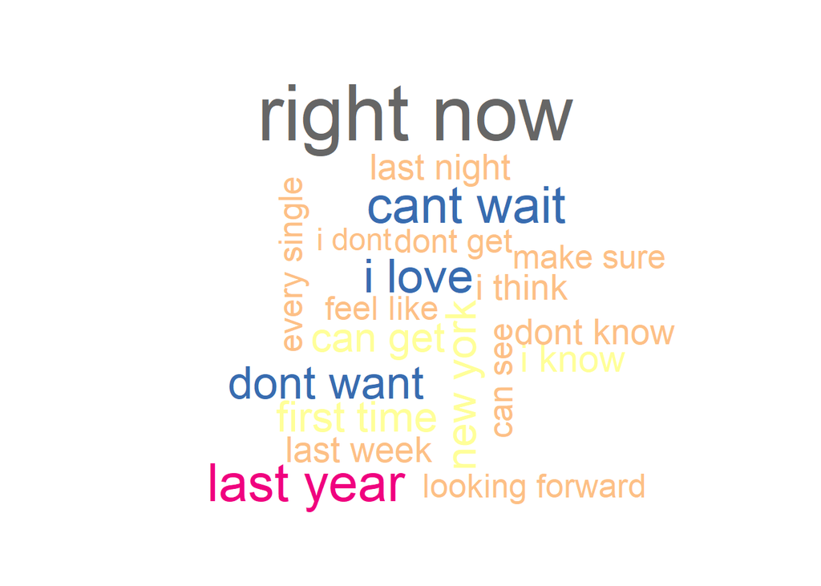

Plot: Word Cloud 3-gram

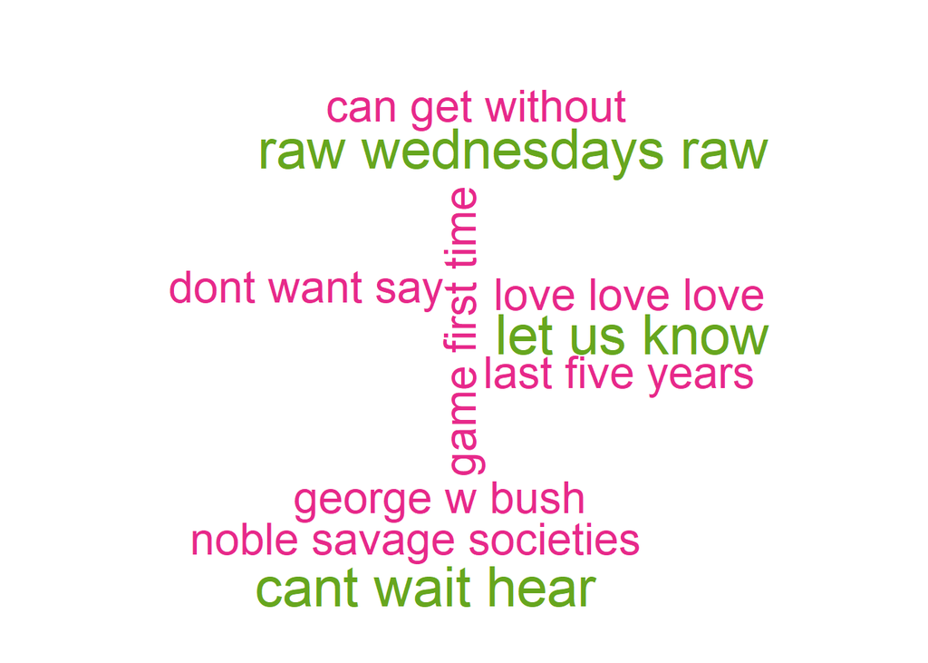

```r
words <- names(frequency3)
wordcloud(words[1:100], frequency3[1:100],colors=brewer.pal(8,"Dark2"))
```

#Task 3: Modeling

Ngram Analysis Build a model to handle unseen n-grams - in some cases people will want to type a combination of words that does not appear in the corpora. Build a model to handle cases where a particular n-gram isn’t observed.

I did not build a backoff models which is a model which i will look at all previous words in an ngram to predict the next one on conditional probability. I had to work for days dealing with RAM issues and intend to transfer my work to a server.

## report written in a brief, concise style, in a way that a non-data scientist manager could appreciate